# Housing Price Prediction

### Introduction: Housing Price Prediction is all about using smart computer programs to guess how much a house might cost in the future. This is super important because it helps people decide when to buy or sell a house, figure out the right price, and find good investment opportunities.

### Business Question: How can real estate agents predict the selling price of a house based on its various features and characteristics, such as area, number of bedrooms, bathrooms, and other attributes?

### Expected Benefit : It helps in decision making while purchasing the house.

### This project benefits for real estate agents, common man and anyone who is planning to purchase a house by doing some analysis.

# Project Dataset

**Dataset Description (Source : Kaggle)**

**Price:** The price of the house.

**Area:** The total area of the house in square feet.

**Bedrooms:** The number of bedrooms in the house.

**Bathrooms:** The number of bathrooms in the house.

**Stories:** The number of stories in the house.

**Mainroad:** Whether the house is connected to the main road (Yes/No).

**Guestroom:** Whether the house has a guest room (Yes/No).

**Basement:** Whether the house has a basement (Yes/No).

**Hot water heating:** Whether the house has a hot water heating system (Yes/No).

**Airconditioning:** Whether the house has an air conditioning system (Yes/No).

**Parking:** The number of parking spaces available within the house.

**Prefarea:** Whether the house is located in a preferred area (Yes/No).

**Furnishing status:** The furnishing status of the house (Fully Furnished, Semi-Furnished, Unfurnished).

#### Environment Creation

```python
import pandas as pd
import numpy as np
import matplotlib.pyplot as plt
import seaborn as sns

%matplotlib inline

# ignore warnings
import warnings
from pandas.errors import SettingWithCopyWarning
from sklearn.exceptions import ConvergenceWarning
from sklearn.preprocessing import StandardScaler, MinMaxScaler, LabelEncoder

# Ignore all the warnings
warnings.filterwarnings("ignore", category=RuntimeWarning)
warnings.filterwarnings("ignore", category=FutureWarning)
warnings.filterwarnings("ignore", category=SettingWithCopyWarning)
warnings.filterwarnings("ignore", category=ConvergenceWarning)

from sklearn.model_selection import train_test_split
from sklearn.linear_model import LinearRegression
from sklearn.ensemble import RandomForestRegressor
from sklearn.tree import DecisionTreeRegressor
from sklearn.preprocessing import MinMaxScaler
from sklearn.metrics import mean_squared_error, mean_absolute_error, r2_score
```

#### Loading dataset

```python
df = pd.read_csv("Housing.csv")

df.head()
```

|  | price | area | bedrooms | bathrooms | stories | mainroad | guestroom | basement | hotwaterheating | airconditioning | parking | prefarea | furnishingstatus |
| --- | --- | --- | --- | --- | --- | --- | --- | --- | --- | --- | --- | --- | --- |
| 0 | 13300000 | 7420 | 4 | 2 | 3 | yes | no | no | no | yes | 2 | yes | furnished |
| 1 | 12250000 | 8960 | 4 | 4 | 4 | yes | no | no | no | yes | 3 | no | furnished |
| 2 | 12250000 | 9960 | 3 | 2 | 2 | yes | no | yes | no | no | 2 | yes | semi-furnished |
| 3 | 12215000 | 7500 | 4 | 2 | 2 | yes | no | yes | no | yes | 3 | yes | furnished |
| 4 | 11410000 | 7420 | 4 | 1 | 2 | yes | yes | yes | no | yes | 2 | no | furnished |

#### Dimensions of the Dataset

```python
df.shape
```

```
(545, 13)
```

#### Basic information of the Dataset

```python
df.info()
```

```
<class 'pandas.core.frame.DataFrame'>
RangeIndex: 545 entries, 0 to 544
Data columns (total 13 columns):
 #   Column            Non-Null Count  Dtype
---  ------            --------------  -----
 0   price             545 non-null    int64
 1   area              545 non-null    int64
 2   bedrooms          545 non-null    int64
 3   bathrooms         545 non-null    int64
 4   stories           545 non-null    int64
 5   mainroad          545 non-null    object
 6   guestroom         545 non-null    object
 7   basement          545 non-null    object
 8   hotwaterheating   545 non-null    object
 9   airconditioning   545 non-null    object
 10  parking           545 non-null    int64
 11  prefarea          545 non-null    object
 12  furnishingstatus  545 non-null    object
dtypes: int64(6), object(7)
memory usage: 55.5+ KB
```

#### Descriptive Statistics

```python
df.describe()
```

|  | price | area | bedrooms | bathrooms | stories | parking |
| --- | --- | --- | --- | --- | --- | --- |
| count | 5.450000e+02 | 545.000000 | 545.000000 | 545.000000 | 545.000000 | 545.000000 |
| mean | 4.766729e+06 | 5150.541284 | 2.965138 | 1.286239 | 1.805505 | 0.693578 |
| std | 1.870440e+06 | 2170.141023 | 0.738064 | 0.502470 | 0.867492 | 0.861586 |
| min | 1.750000e+06 | 1650.000000 | 1.000000 | 1.000000 | 1.000000 | 0.000000 |
| 25% | 3.430000e+06 | 3600.000000 | 2.000000 | 1.000000 | 1.000000 | 0.000000 |
| 50% | 4.340000e+06 | 4600.000000 | 3.000000 | 1.000000 | 2.000000 | 0.000000 |
| 75% | 5.740000e+06 | 6360.000000 | 3.000000 | 2.000000 | 2.000000 | 1.000000 |
| max | 1.330000e+07 | 16200.000000 | 6.000000 | 4.000000 | 4.000000 | 3.000000 |

# Data Analysis

#### What is the average price of houses located on the main road?

```python
average_price_mainroad = df[df['mainroad'] == 'yes']['price'].mean()
print("Average price of houses on the main road:", average_price_mainroad)
```

```
Average price of houses on the main road: 4991777.329059829
```

#### What is the average area size of houses that have a guestroom?

```python
average_area_with_guestroom = df[df['guestroom'] == 'yes']['area'].mean()
print("Average area size of houses with a guestroom:", average_area_with_guestroom)
```

```
Average area size of houses with a guestroom: 5804.257731958763
```

#### What is the number of stories typically found in houses that are not on the main road?

```python
stories_not_on_mainroad = df[df['mainroad'] == 'no']['stories'].value_counts()
print("Number of stories in houses not on the main road:")
print(stories_not_on_mainroad)
```

```
Number of stories in houses not on the main road:
stories
2    38
1    37
3     2
Name: count, dtype: int64
```

#### What is the average number of parking spaces available in fully furnished houses?

```python
average_parking_fully_furnished = df[df['furnishingstatus'] == 'furnished']['parking'].mean()
print("Average number of parking spaces in fully furnished houses:", average_parking_fully_furnished)
```

```
Average number of parking spaces in fully furnished houses: 0.8857142857142857
```

#### What is the average number of bathrooms for semi-furnished and fully furnished houses and compare them?

```python
average_bathrooms_semi_furnished = df[df['furnishingstatus'] == 'semi-furnished']['bathrooms'].mean()
average_bathrooms_fully_furnished = df[df['furnishingstatus'] == 'furnished']['bathrooms'].mean()

print("Average number of bathrooms in semi-furnished houses:", average_bathrooms_semi_furnished)
print("Average number of bathrooms in fully furnished houses:", average_bathrooms_fully_furnished)
```

```
Average number of bathrooms in semi-furnished houses: 1.303964757709251
Average number of bathrooms in fully furnished houses: 1.3785714285714286
```

#### What is the percentage of houses with hot water heating that also have air conditioning?

```python
hot_water_and_ac = df[(df['hotwaterheating'] == 'yes') & (df['airconditioning'] == 'yes')]
percentage_with_ac = (len(hot_water_and_ac) / len(df[df['hotwaterheating'] == 'yes'])) * 100
print("Percentage of houses with hot water heating and air conditioning:", percentage_with_ac)
```

```
Percentage of houses with hot water heating and air conditioning: 4.0
```

# Data Visualization

#### Stacked Bar Chart: Showing the distribution of bedrooms in furnished vs. unfurnished houses

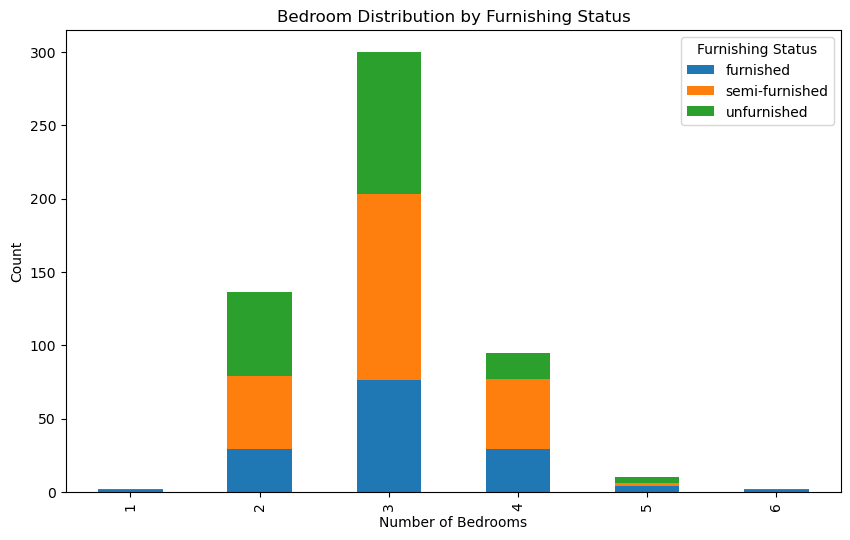

```python
import matplotlib.pyplot as plt
import seaborn as sns

pivot_table = df.pivot_table(index='bedrooms', columns='furnishingstatus', values='price', aggfunc='count')

ax = pivot_table.plot(kind='bar', stacked=True, figsize=(10, 6))
plt.title('Bedroom Distribution by Furnishing Status')
plt.xlabel('Number of Bedrooms')
plt.ylabel('Count')
plt.legend(title='Furnishing Status', loc='upper right')
plt.show()
```

#### Pie Chart: Visualizing the distribution of houses with or without a guestroom

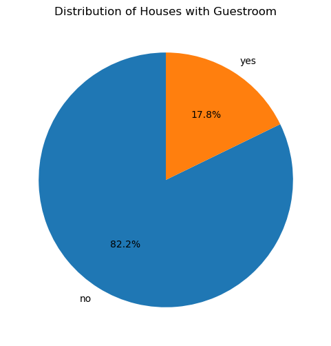

```python
guestroom_counts = df['guestroom'].value_counts()
plt.figure(figsize=(6, 6))
plt.pie(guestroom_counts, labels=guestroom_counts.index, autopct='%1.1f%%', startangle=90)
plt.title('Distribution of Houses with Guestroom')
plt.show()
```

#### Scatter Plot: Comparing the total area of the house with its price, also considering whether the house is in mainroad or not

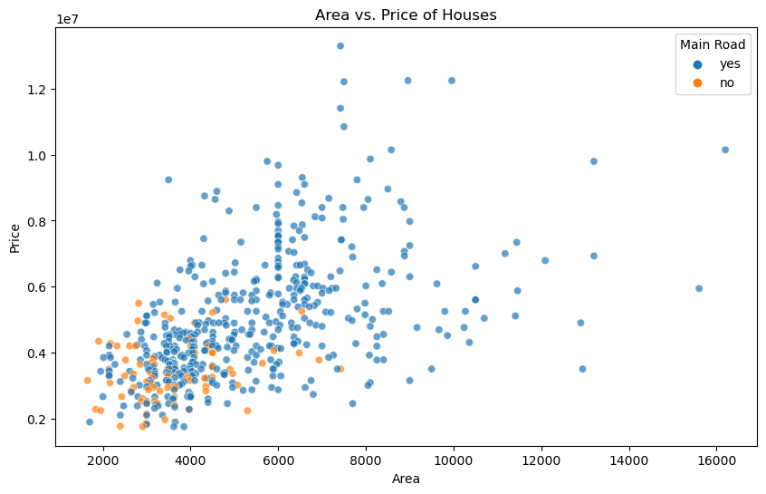

```python
plt.figure(figsize=(10, 6))
sns.scatterplot(data=df, x='area', y='price', hue='mainroad', alpha=0.7)
plt.title('Area vs. Price of Houses')
plt.xlabel('Area')
plt.ylabel('Price')
plt.legend(title='Main Road', loc='upper right')
plt.show()
```

#### Count plot: Visualizing the status of Furnishing

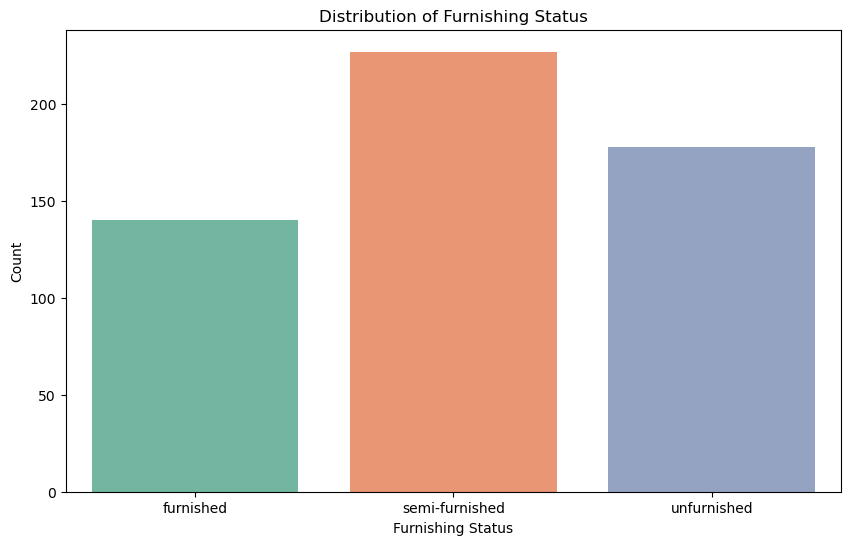

```python
plt.figure(figsize=(10, 6))


sns.countplot(data=df, x='furnishingstatus', palette='Set2')
plt.title('Distribution of Furnishing Status')
plt.xlabel('Furnishing Status')
plt.ylabel('Count')
plt.show()
```

# Data Preprocessing

#### Data Cleaning : Check for missing values

```python
missing_values = df.isnull().sum()
print("Missing Values:")
print(missing_values)
```

```
Missing Values:
price               0
area                0
bedrooms            0
bathrooms           0
stories             0
mainroad            0
guestroom           0
basement            0
hotwaterheating     0
airconditioning     0
parking             0
prefarea            0
furnishingstatus    0
dtype: int64
```

#### Identify categorical columns

```python
categorical_columns = df.select_dtypes(include=['object', 'category']).columns.tolist()

print("Categorical Columns:")
print(categorical_columns)
```

```
Categorical Columns:
['mainroad', 'guestroom', 'basement', 'hotwaterheating', 'airconditioning', 'prefarea', 'furnishingstatus']
```

#### Mapping values for furnishingstatus

```python
furnishingstatus_mapping = {
    'unfurnished': 0,
    'semi-furnished': 1,
    'furnished': 2
}

df['furnishingstatus'] = df['furnishingstatus'].map(furnishingstatus_mapping)
df
```

|  | price | area | bedrooms | bathrooms | stories | mainroad | guestroom | basement | hotwaterheating | airconditioning | parking | prefarea | furnishingstatus |
| --- | --- | --- | --- | --- | --- | --- | --- | --- | --- | --- | --- | --- | --- |
| 0 | 13300000 | 7420 | 4 | 2 | 3 | yes | no | no | no | yes | 2 | yes | 2 |
| 1 | 12250000 | 8960 | 4 | 4 | 4 | yes | no | no | no | yes | 3 | no | 2 |
| 2 | 12250000 | 9960 | 3 | 2 | 2 | yes | no | yes | no | no | 2 | yes | 1 |
| 3 | 12215000 | 7500 | 4 | 2 | 2 | yes | no | yes | no | yes | 3 | yes | 2 |
| 4 | 11410000 | 7420 | 4 | 1 | 2 | yes | yes | yes | no | yes | 2 | no | 2 |
| ... | ... | ... | ... | ... | ... | ... | ... | ... | ... | ... | ... | ... | ... |
| 540 | 1820000 | 3000 | 2 | 1 | 1 | yes | no | yes | no | no | 2 | no | 0 |
| 541 | 1767150 | 2400 | 3 | 1 | 1 | no | no | no | no | no | 0 | no | 1 |
| 542 | 1750000 | 3620 | 2 | 1 | 1 | yes | no | no | no | no | 0 | no | 0 |
| 543 | 1750000 | 2910 | 3 | 1 | 1 | no | no | no | no | no | 0 | no | 2 |
| 544 | 1750000 | 3850 | 3 | 1 | 2 | yes | no | no | no | no | 0 | no | 0 |

545 rows × 13 columns

#### Performing one-hot encoding for categorical columns

```python
categorical_columns = ['mainroad', 'guestroom', 'basement', 'hotwaterheating', 'airconditioning', 'prefarea']
df = pd.get_dummies(df, columns=categorical_columns, drop_first=True,dtype=int)
df
```

|  | price | area | bedrooms | bathrooms | stories | parking | furnishingstatus | mainroad_yes | guestroom_yes | basement_yes | hotwaterheating_yes | airconditioning_yes | prefarea_yes |
| --- | --- | --- | --- | --- | --- | --- | --- | --- | --- | --- | --- | --- | --- |
| 0 | 13300000 | 7420 | 4 | 2 | 3 | 2 | 2 | 1 | 0 | 0 | 0 | 1 | 1 |
| 1 | 12250000 | 8960 | 4 | 4 | 4 | 3 | 2 | 1 | 0 | 0 | 0 | 1 | 0 |
| 2 | 12250000 | 9960 | 3 | 2 | 2 | 2 | 1 | 1 | 0 | 1 | 0 | 0 | 1 |
| 3 | 12215000 | 7500 | 4 | 2 | 2 | 3 | 2 | 1 | 0 | 1 | 0 | 1 | 1 |
| 4 | 11410000 | 7420 | 4 | 1 | 2 | 2 | 2 | 1 | 1 | 1 | 0 | 1 | 0 |
| ... | ... | ... | ... | ... | ... | ... | ... | ... | ... | ... | ... | ... | ... |
| 540 | 1820000 | 3000 | 2 | 1 | 1 | 2 | 0 | 1 | 0 | 1 | 0 | 0 | 0 |
| 541 | 1767150 | 2400 | 3 | 1 | 1 | 0 | 1 | 0 | 0 | 0 | 0 | 0 | 0 |
| 542 | 1750000 | 3620 | 2 | 1 | 1 | 0 | 0 | 1 | 0 | 0 | 0 | 0 | 0 |
| 543 | 1750000 | 2910 | 3 | 1 | 1 | 0 | 2 | 0 | 0 | 0 | 0 | 0 | 0 |
| 544 | 1750000 | 3850 | 3 | 1 | 2 | 0 | 0 | 1 | 0 | 0 | 0 | 0 | 0 |

545 rows × 13 columns

### Test the validity and reliability of linear models for this dataset

#### Building the linear model (OLS)

```python
import statsmodels.api as sm

# Define the dependent variable (target) and independent variables (features)
X = df.drop('price', axis=1)
y = df['price']

# Add a constant (intercept) to the features
X = sm.add_constant(X)

# Create and fit the OLS model
model = sm.OLS(y, X).fit()

# Get the summary of the model
summary = model.summary()

# Display the summary
print(summary)
```

```
                            OLS Regression Results
==============================================================================
Dep. Variable:                  price   R-squared:                       0.680
Model:                            OLS   Adj. R-squared:                  0.673
Method:                 Least Squares   F-statistic:                     94.24
Date:                Fri, 15 Dec 2023   Prob (F-statistic):          3.81e-123
Time:                        16:25:03   Log-Likelihood:                -8333.0
No. Observations:                 545   AIC:                         1.669e+04
Df Residuals:                     532   BIC:                         1.675e+04
Df Model:                          12
Covariance Type:            nonrobust
=======================================================================================
                          coef    std err          t      P>|t|      [0.025      0.975]
---------------------------------------------------------------------------------------
const               -3.245e+05   2.37e+05     -1.370      0.171    -7.9e+05    1.41e+05
area                  243.9069     24.332     10.024      0.000     196.109     291.705
bedrooms             1.195e+05   7.27e+04      1.644      0.101   -2.33e+04    2.62e+05
bathrooms            9.889e+05   1.04e+05      9.551      0.000    7.85e+05    1.19e+06
stories              4.504e+05   6.43e+04      7.006      0.000    3.24e+05    5.77e+05
parking              2.798e+05   5.86e+04      4.774      0.000    1.65e+05    3.95e+05
furnishingstatus     2.132e+05   6.31e+04      3.381      0.001    8.93e+04    3.37e+05
mainroad_yes         4.231e+05   1.42e+05      2.970      0.003    1.43e+05    7.03e+05
guestroom_yes         2.98e+05   1.32e+05      2.259      0.024    3.89e+04    5.57e+05
basement_yes         3.579e+05    1.1e+05      3.243      0.001    1.41e+05    5.75e+05
hotwaterheating_yes  8.729e+05   2.23e+05      3.909      0.000    4.34e+05    1.31e+06
airconditioning_yes  8.536e+05   1.08e+05      7.879      0.000    6.41e+05    1.07e+06
prefarea_yes         6.471e+05   1.16e+05      5.585      0.000    4.19e+05    8.75e+05
==============================================================================
Omnibus:                       94.906   Durbin-Watson:                   1.209
Prob(Omnibus):                  0.000   Jarque-Bera (JB):              247.728
Skew:                           0.872   Prob(JB):                     1.61e-54
Kurtosis:                       5.805   Cond. No.                     3.07e+04
==============================================================================

Notes:
[1] Standard Errors assume that the covariance matrix of the errors is correctly specified.
[2] The condition number is large, 3.07e+04. This might indicate that there are
strong multicollinearity or other numerical problems.
```

#### The five assumptions of linear regression

```python
# Assumption 1: Linearity test (2 points)
from statsmodels.stats.diagnostic import linear_rainbow

# Perform the Rainbow test on your 'model' (your linear regression model)
rainbow_stat, rainbow_p_value = linear_rainbow(model)

# Print the results
print(f'Rainbow statistic: {rainbow_stat}')
print(f'Rainbow p-value: {rainbow_p_value}')
print("Rejecting H₀: The relationship between the independent variables (IVs) and dependent variable (DV) is linear."
      if rainbow_p_value < 0.05
      else "Accepting H₀: The relationship between the IVs and DV is non-linear.")
```

```
Rainbow statistic: 7.475640376082441
Rainbow p-value: 4.426265713985289e-52
Rejecting H₀: The relationship between the independent variables (IVs) and dependent variable (DV) is linear.
```

```python
# Assumption 2: Independence of errors (Autocorrelations) (2 points)

# Compute the Durbin-Watson test statistic
durbin_watson = sm.stats.stattools.durbin_watson(model.resid)

# Print the test statistic
print("Durbin-Watson test statistic:", durbin_watson)
print("Positive autocorrelation"
      if durbin_watson < 2 else "Negative autocorrelation"
      if durbin_watson > 2 else "No autocorrelation")
```

```
Durbin-Watson test statistic: 1.2091156731072132
Positive autocorrelation
```

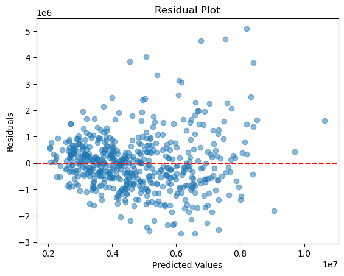

```python
# Assumption 3: Homoscedasticity/ Heteroscedasticity test (2 points)
# AssertionError may raise for White test
plt.scatter(model.predict(), model.resid, alpha=0.5)
plt.axhline(y=0, color='r', linestyle='--')
plt.xlabel('Predicted Values')
plt.ylabel('Residuals')
plt.title('Residual Plot')
plt.show()
```

```python
# Assumption 4: Normality test (2 points)
import scipy.stats as stats

# Shapiro test for testing the normality
test_stat_normality, p_value_normality=stats.shapiro(model.resid) # all IVs: X = boston_df_new.drop(columns=['PRICE'])
print("p value:%.2f" % p_value_normality)
print("The data is not normally distributed" if p_value_normality < 0.05
       else "The data is normally distributed")
```

```
p value:0.00
The data is not normally distributed
```

```python
# Assumption 5: Multicollinearity test
from statsmodels.stats.outliers_influence import variance_inflation_factor

# Create a DataFrame for VIF calculation
vif_data = df.copy()

# Drop the target variable
vif_data.drop('price', axis=1, inplace=True)

# Calculate VIF for each feature
vif = pd.DataFrame()
vif["Feature"] = vif_data.columns
vif["VIF"] = [variance_inflation_factor(vif_data.values, i) for i in range(vif_data.shape[1])]

# Display the VIF values
print(vif)
```

```
                Feature        VIF
0                  area   8.274080
1              bedrooms  15.293315
2             bathrooms   9.429678
3               stories   7.886990
4               parking   1.959942
5      furnishingstatus   2.727003
6          mainroad_yes   6.871438
7         guestroom_yes   1.468460
8          basement_yes   2.022168
9   hotwaterheating_yes   1.089201
10  airconditioning_yes   1.748656
11         prefarea_yes   1.486713
```

```python
# Step 1: Improve the Normality of the Data (Log-Transform Skewed Numeric Data)

# Log-transform positively skewed numeric data
skewed_vars = df.select_dtypes(include=['int64', 'float64']).apply(lambda x: stats.skew(x))
skewed_vars = skewed_vars[abs(skewed_vars) > 0.5]  # Adjust the skewness threshold as needed

for var in skewed_vars.index:
    if (var != 'price') and (min(df[var]) > 0):
        df[var] = np.log1p(df[var])

# Step 2: Reduce Multicollinearity (Remove Highly Correlated Variables)

# Calculate and visualize the correlation matrix
corr_matrix = df.corr()

# Identify highly correlated variables (e.g., correlation > 0.7)
highly_correlated = set()
for i in range(len(corr_matrix.columns)):
    for j in range(i):
        if abs(corr_matrix.iloc[i, j]) > 0.7:
            colname = corr_matrix.columns[i]
            highly_correlated.add(colname)

# Remove highly correlated variables
df_cleaned = df.drop(columns=highly_correlated)

# Rebuild the linear model with the cleaned data
X_cleaned = df_cleaned.drop('price', axis=1)
y_cleaned = df_cleaned['price']

X_cleaned = sm.add_constant(X_cleaned)
model_cleaned = sm.OLS(y_cleaned, X_cleaned).fit()

# Get the summary of the cleaned model
summary_cleaned = model_cleaned.summary()

# Display the summary of the cleaned model
print(summary_cleaned)
```

```
                            OLS Regression Results
==============================================================================
Dep. Variable:                  price   R-squared:                       0.679
Model:                            OLS   Adj. R-squared:                  0.672
Method:                 Least Squares   F-statistic:                     93.99
Date:                Fri, 15 Dec 2023   Prob (F-statistic):          6.14e-123
Time:                        16:25:04   Log-Likelihood:                -8333.5
No. Observations:                 545   AIC:                         1.669e+04
Df Residuals:                     532   BIC:                         1.675e+04
Df Model:                          12
Covariance Type:            nonrobust
=======================================================================================
                          coef    std err          t      P>|t|      [0.025      0.975]
---------------------------------------------------------------------------------------
const               -1.242e+07   1.11e+06    -11.176      0.000   -1.46e+07   -1.02e+07
area                 1.445e+06   1.36e+05     10.594      0.000    1.18e+06    1.71e+06
bedrooms             1.023e+05   7.44e+04      1.375      0.170   -4.38e+04    2.49e+05
bathrooms            2.534e+06   2.68e+05      9.457      0.000    2.01e+06    3.06e+06
stories              1.318e+06   1.97e+05      6.704      0.000    9.32e+05     1.7e+06
parking               2.79e+05   5.88e+04      4.748      0.000    1.64e+05    3.94e+05
furnishingstatus     2.185e+05   6.31e+04      3.462      0.001    9.45e+04    3.42e+05
mainroad_yes         3.322e+05   1.44e+05      2.301      0.022    4.86e+04    6.16e+05
guestroom_yes         2.36e+05   1.33e+05      1.778      0.076   -2.47e+04    4.97e+05
basement_yes         3.548e+05    1.1e+05      3.224      0.001    1.39e+05    5.71e+05
hotwaterheating_yes  8.557e+05   2.24e+05      3.826      0.000    4.16e+05     1.3e+06
airconditioning_yes  8.203e+05   1.09e+05      7.557      0.000    6.07e+05    1.03e+06
prefarea_yes         6.701e+05   1.15e+05      5.804      0.000    4.43e+05    8.97e+05
==============================================================================
Omnibus:                       90.858   Durbin-Watson:                   1.202
Prob(Omnibus):                  0.000   Jarque-Bera (JB):              225.288
Skew:                           0.854   Prob(JB):                     1.20e-49
Kurtosis:                       5.646   Cond. No.                         226.
==============================================================================

Notes:
[1] Standard Errors assume that the covariance matrix of the errors is correctly specified.
```

```python
df_cleaned
```

|  | price | area | bedrooms | bathrooms | stories | parking | furnishingstatus | mainroad_yes | guestroom_yes | basement_yes | hotwaterheating_yes | airconditioning_yes | prefarea_yes |
| --- | --- | --- | --- | --- | --- | --- | --- | --- | --- | --- | --- | --- | --- |
| 0 | 13300000 | 8.912069 | 4 | 1.098612 | 1.386294 | 2 | 2 | 1 | 0 | 0 | 0 | 1 | 1 |
| 1 | 12250000 | 9.100637 | 4 | 1.609438 | 1.609438 | 3 | 2 | 1 | 0 | 0 | 0 | 1 | 0 |
| 2 | 12250000 | 9.206433 | 3 | 1.098612 | 1.098612 | 2 | 1 | 1 | 0 | 1 | 0 | 0 | 1 |
| 3 | 12215000 | 8.922792 | 4 | 1.098612 | 1.098612 | 3 | 2 | 1 | 0 | 1 | 0 | 1 | 1 |
| 4 | 11410000 | 8.912069 | 4 | 0.693147 | 1.098612 | 2 | 2 | 1 | 1 | 1 | 0 | 1 | 0 |
| ... | ... | ... | ... | ... | ... | ... | ... | ... | ... | ... | ... | ... | ... |
| 540 | 1820000 | 8.006701 | 2 | 0.693147 | 0.693147 | 2 | 0 | 1 | 0 | 1 | 0 | 0 | 0 |
| 541 | 1767150 | 7.783641 | 3 | 0.693147 | 0.693147 | 0 | 1 | 0 | 0 | 0 | 0 | 0 | 0 |
| 542 | 1750000 | 8.194506 | 2 | 0.693147 | 0.693147 | 0 | 0 | 1 | 0 | 0 | 0 | 0 | 0 |
| 543 | 1750000 | 7.976252 | 3 | 0.693147 | 0.693147 | 0 | 2 | 0 | 0 | 0 | 0 | 0 | 0 |
| 544 | 1750000 | 8.256088 | 3 | 0.693147 | 1.098612 | 0 | 0 | 1 | 0 | 0 | 0 | 0 | 0 |

545 rows × 13 columns

## Machine Learning

#### split the data into (50%, 70%, 75%, 80%) training data and (50%, 30%, 25%, 20%) testing data and compare the models.

```python
from sklearn.model_selection import train_test_split
from sklearn.metrics import r2_score, mean_absolute_error, mean_squared_error
import sklearn.linear_model as lm

# Split the data into training and testing sets
# Split the data into a 50-50 train-test split
X_train, X_test, y_train, y_test = train_test_split(X_cleaned, y_cleaned, test_size=0.5, random_state=0)

# Create and train a linear regression model
linear_model = lm.LinearRegression()
linear_model.fit(X_train, y_train)

# Predict the target variable on the test set
y_pred = linear_model.predict(X_test)

# Evaluate the model performance
r2 = r2_score(y_test, y_pred)
mae = mean_absolute_error(y_test, y_pred)
mse = mean_squared_error(y_test, y_pred)
rmse = np.sqrt(mse)

print("R-squared:", r2)
print("MAE:", mae)
print("MSE:", mse)
print("RMSE:", rmse)
```

```
R-squared: 0.6894516362610772
MAE: 774437.8229089743
MSE: 1114214441102.2148
RMSE: 1055563.5656379084
```

```python
# Split the data into a 70-30 train-test split
X_train_70, X_test_30, y_train_70, y_test_30 = train_test_split(X_cleaned, y_cleaned, test_size=0.3, random_state=0)

# Create and train a linear regression model
linear_model_70 = lm.LinearRegression()
linear_model_70.fit(X_train_70, y_train_70)

# Predict the target variable on the test set
y_pred_30 = linear_model_70.predict(X_test_30)

# Evaluate the model performance
r2_30 = r2_score(y_test_30, y_pred_30)
mae_30 = mean_absolute_error(y_test_30, y_pred_30)
mse_30 = mean_squared_error(y_test_30, y_pred_30)
rmse_30 = np.sqrt(mse_30)

print("R-squared:", r2_30)
print("MAE:", mae_30)
print("MSE:", mse_30)
print("RMSE:", rmse_30)
```

```
R-squared: 0.7152788700536039
MAE: 737086.8967780792
MSE: 987633405585.8716
RMSE: 993797.467085659
```

```python
# Split the data into a 75-25 train-test split
X_train_75, X_test_25, y_train_75, y_test_25 = train_test_split(X, y, test_size=0.25, random_state=0)

linear_75 = lm.LinearRegression()
linear_75.fit(X_train_75, y_train_75)

y_pred_25 = linear_75.predict(X_test_25)

r2_25 = r2_score(y_test_25, y_pred_25)
mae_25 = mean_absolute_error(y_test_25, y_pred_25)
mse_25 = mean_squared_error(y_test_25, y_pred_25)
rmse_25 = np.sqrt(mse_25)

print("R-squared :", r2_25)
print("MAE :", mae_25)
print("MSE :", mse_25)
print("RMSE :", rmse_25)
```

```
R-squared : 0.6965206541388422
MAE : 714030.2109784862
MSE : 936684599757.6586
RMSE : 967824.6740797935
```

```python
# Split the data into a 80-20 train-test split
X_train_80, X_test_20, y_train_80, y_test_20 = train_test_split(X, y, test_size=0.2, random_state=0)

linear_80 = lm.LinearRegression()
linear_80.fit(X_train_80, y_train_80)

y_pred_20 = linear_80.predict(X_test_20)

r2_20 = r2_score(y_test_20, y_pred_20)
mae_20 = mean_absolute_error(y_test_20, y_pred_20)
mse_20 = mean_squared_error(y_test_20, y_pred_20)
rmse_20 = np.sqrt(mse_20)

print("R-squared :", r2_20)
print("MAE :", mae_20)
print("MSE :", mse_20)
print("RMSE :", rmse_20)
```

```
R-squared : 0.6578047592637566
MAE : 716583.439661554
MSE : 986041803890.0352
RMSE : 992996.3765744743
```

## Conclusion

### Real Estate Agents can use the Machine learning method impplementing Linear Regression Analysis like this for better prediction of the Housing Prices